# Análisis de autocorrelación espacial

Juan José Galeano Arenas

Simón Pedro Galeano Muñoz

Germán Alonso Patiño Hurtado

12/05/2022

# Datos

El invierno es feroz, más aún cuando de agricultura se trata. Indiana, estado precioso cuyo mayor costo de [producción agrícola](https://www.nass.usda.gov/Quick_Stats/Ag_Overview/stateOverview.php?state=INDIANA) se debe al cultivo de maíz.

Motivados por este hecho, se tomó la decisión de investigar cuáles son aquellas zonas en las que se presenta una mayor temperatura y una mayor irradiación por parte de la radiación que emite la luz solar, ya que el maíz es un vegetal que aprovecha mucho ambas características para su [crecimiento y desarrollo](https://www.pioneer.com/us/agronomy/soil_temp_corn_emergence.html#:~:text=Key%20Points,corn%20emergence%20and%20seedling%20health.).

# Temperatura e irradiación solar

Se miden las variables irradiación solar y temperatura en ubicaciones especificas del estado de indiana en estados unidos múltiples veces (90 en cada punto); dichas mediciones se realizan en ubicaciones igualmente espaciadas.

# Base de datos definitiva

La base de datos definitiva se construye agrupando los datos por la longitud y latitud debido a que, como se mencionó previamente, se tienen múltiples mediciones de las variables en cada ubicación los cuales corresponden a los primeros tres meses del año, una vez agrupadas las ubicaciones, se promedian todos los valores medidos en dichas ubicaciones de las variables de interés, esto gracias a las funciones `group_by()` y `summarise()` de la librería `dplyr`.

```r
mapa_base <- leaflet() %>%
  addTiles()

mapa_base %>%
  addCircleMarkers(lat=~LAT, lng =~LON,
                   color = "red", radius = 0.5, data = datos_cools)
```

[interactive chart not shown]

## Análisis descriptivo y prueba de autocorrelación espacial

En esta sección se verifica el supuesto de autocorrelación espacial, el cual es fundamental al momento de realizar análisis posteriores. Se hace la aclaración que para este caso particular se trabajará con la variable temperatura.

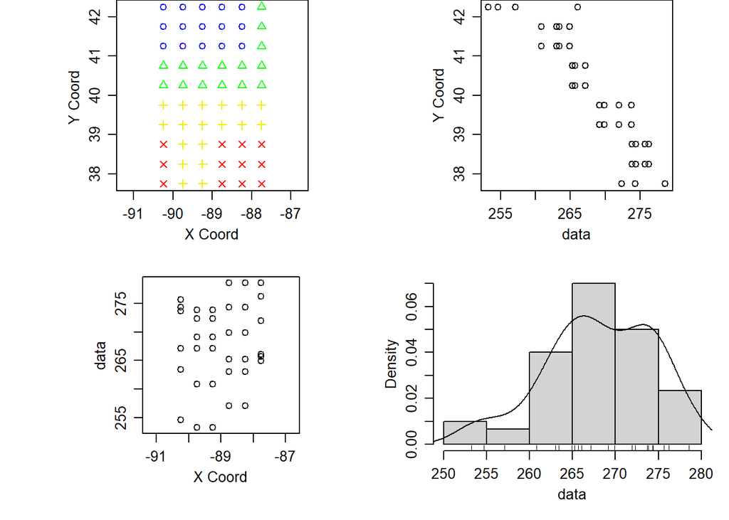

- En la figura superior izquierda se aprecian las ubicaciones muestreadas coloreadas en función del cuartil al que pertenecen; se puede notar que las ubicaciones cercanas entre sí están coloreadas con el mismo color sugiriendo esto que dichas ubicaciones tienen temperaturas similares y por lo tanto es probable que exista autocorrelación espacial.
- Para la figura superior derecha se aprecia una clara asociación lineal entre la temperatura y la latitud, sugiriendo la existencia de autocorrelación.
- En el gráfico inferior izquierdo no se aprecia algún tipo de asociación evidente.
- El histograma en la gráfica inferior derecha no entrega mucha información debibdo a que este es algo plano.

### Mantel

Para el test de mantel, se tienen ñas siguientes hipótesis

$$\begin{cases}
H_0: \text{No hay autocorrelación espacial en la variable temperatura}
\\
H_1: \text{Existe autocorrelación espacial en la variable temperatura}
\end{cases}$$

```r
distancia <- dist(cbind(datos_cools$LON,datos_cools$LAT),
                  diag=TRUE,upper=TRUE)
dist.datos <- dist(datos_cools$Temperatura,
                   diag=TRUE, upper=TRUE)^2
mantel(distancia, dist.datos)
```

```
##
## Mantel statistic based on Pearson's product-moment correlation
##
## Call:
## mantel(xdis = distancia, ydis = dist.datos)
##
## Mantel statistic r: 0.8027
##       Significance: 0.001
##
## Upper quantiles of permutations (null model):
##    90%    95%  97.5%    99%
## 0.0529 0.0745 0.0904 0.1088
## Permutation: free
## Number of permutations: 999
```

Teniendo en cuenta la existencia de autocorrelación espacial, es posible usar el método Krigging para realizar predicciones de temperaturas.

```r
summary(distancia)
```

```
##    Min. 1st Qu.  Median    Mean 3rd Qu.    Max.
##   0.500   1.414   2.062   2.137   2.915   5.148
```

```r
variograma=variog(datos_geo,option = "bin",
                  uvec = seq(0,2.9,0.3),messages=F)

## bandas de confianza, si hay o no autocorrelacion
variograma.emv=variog.mc.env(datos_geo,obj=variograma)
```

```
## variog.env: generating 99 simulations by permutating data values
## variog.env: computing the empirical variogram for the 99 simulations
## variog.env: computing the envelops
```

```r
ini.vals <- expand.grid(seq(20,60,l=10), seq(2,2.9,l=10))
model_mco_exp=variofit(variograma, ini=ini.vals, cov.model="exponential",
                       wei="npair", min="optim")
model_mco_gaus=variofit(variograma, ini=ini.vals, cov.model="gaussian",
                        wei="npair", min="optim",nugget = 0)
model_mco_spe=variofit(variograma, ini=ini.vals,
                       cov.model="spheric",fix.nug=TRUE,
                       wei="npair", min="optim")
```

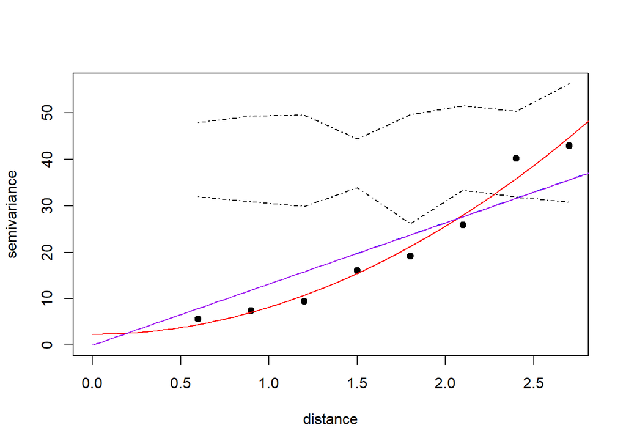

```r
plot(variograma,envelope=variograma.emv,pch=19)
lines(model_mco_exp,col="blue")
lines(model_mco_gaus,col="red")
lines(model_mco_spe,col="purple")
```

```r
valida = xvalid(datos_geo, model = model_mco_gaus)
```

```
## xvalid: number of data locations       = 60
## xvalid: number of validation locations = 60
## xvalid: performing cross-validation at location ... 1, 2, 3, 4, 5, 6, 7, 8, 9, 10, 11, 12, 13, 14, 15, 16, 17, 18, 19, 20, 21, 22, 23, 24, 25, 26, 27, 28, 29, 30, 31, 32, 33, 34, 35, 36, 37, 38, 39, 40, 41, 42, 43, 44, 45, 46, 47, 48, 49, 50, 51, 52, 53, 54, 55, 56, 57, 58, 59, 60,
## xvalid: end of cross-validation
```

```r
mean(valida$error^2)
```

```
## [1] 5.887162
```

# Interpolación IDW

Para realizar interpolación idw en R es importante definir una ventana de observación.

```r
x_obs <- c(min(datos_cools$LON), max(datos_cools$LON))
y_obs <- c(min(datos_cools$LAT), max(datos_cools$LAT))
obs_window <- owin(x_obs, y_obs)
```

Una vez definida la ventana de observación se debe crear un objeto de la clase **ppp** puesto que la función `idw()` del paquete `spatstat.core` funciona con objetos de dicha clase.

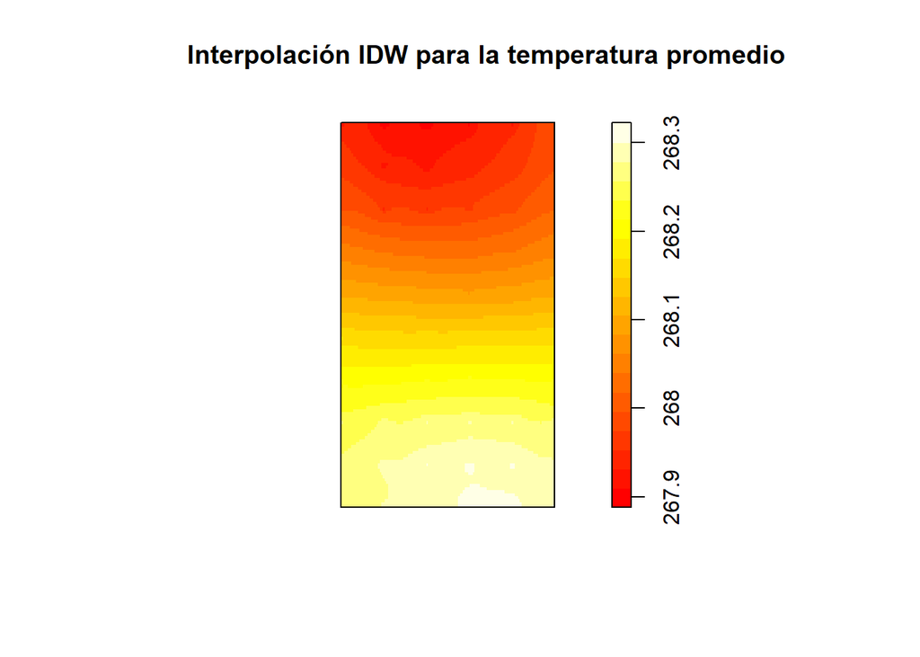

```r
ppp_temp <- ppp(datos_cools$LON, datos_cools$LAT,
                 marks = datos_cools$Irradiacion, window = obs_window)

idw_temp <- idw(ppp_temp, power = 0.05, at = "pixels")

plot(idw_temp,
     col = heat.colors(20),
     main = "Interpolación IDW para la temperatura promedio")
```

# ¿Cómo escoger el valor de p?

A continuación se muestran diferentes interpolaciones para algunos valores de p

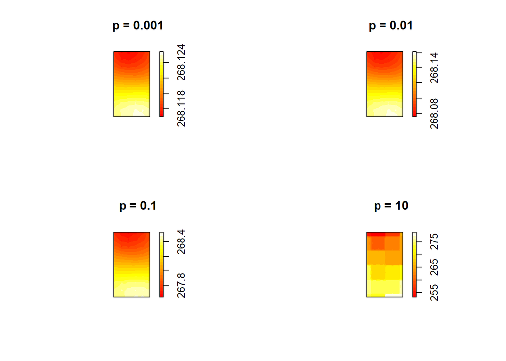

```r
par(mfrow=c(2,2))
plot(idw(ppp_temp, power = 0.001, at = "pixels"),
     col=heat.colors(20), main = "p = 0.001")

plot(idw(ppp_temp, power = 0.01, at = "pixels"),
     col=heat.colors(20), main = "p = 0.01")

plot(idw(ppp_temp, power = 0.1, at = "pixels"),
     col=heat.colors(20), main = "p = 0.1")

plot(idw(ppp_temp, power = 10, at = "pixels"),
     col=heat.colors(20), main = "p = 10")
```

## MSE

El MSE del ajuste puede obtenerse de la siguiente manera

```r
?idw
library(spm)
idw_predicts <- idw(ppp_temp, power = 0.05, at = "points")
Metrics::mse(ppp_temp$marks, idw_predicts)
```

```
## [1] 39.05949
```

```r
lol <- idwcv(datos_cools[,1:2],datos_cools[,4], cv.fold =  2,idp = 1)
```

```
## [inverse distance weighted interpolation]
## [inverse distance weighted interpolation]
```

## Buscando la potencia óptima con Grid - Search

Se calcula el MSE con una gran variedad de valores de p

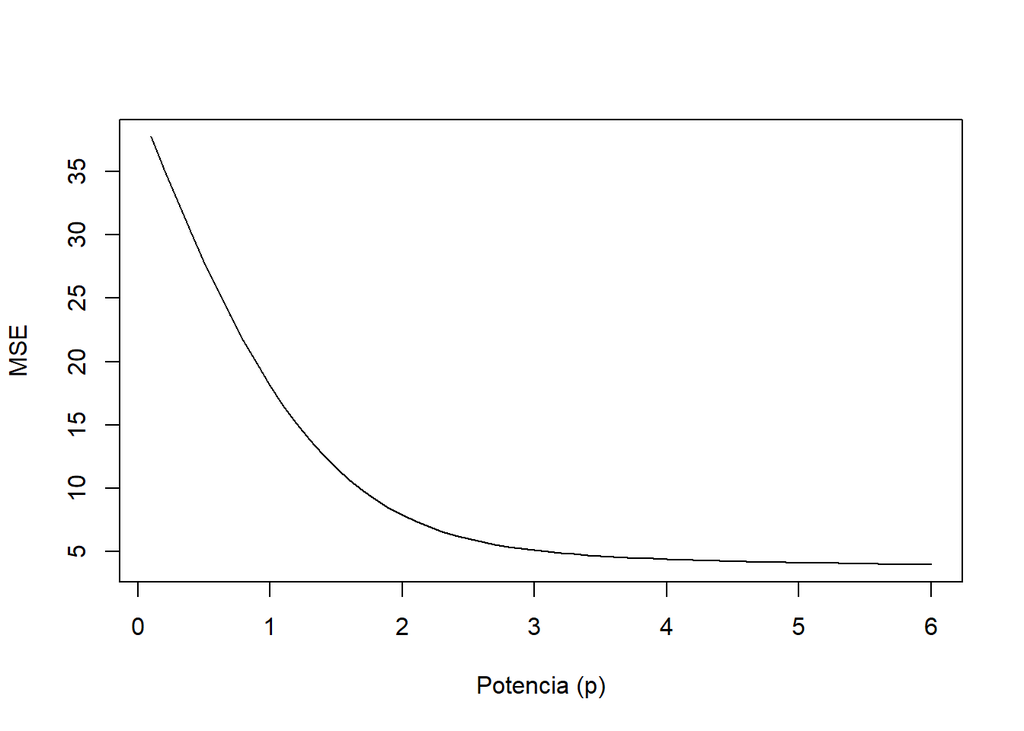

```r
powers <- seq(0.1, 6, 0.1)
mse_result <- numeric(length(powers))
cnt <- 1
for(power in powers){
  CV_idw <- idw(ppp_temp, power=power, at="points")
  mse_result[cnt] <- mean((datos_cools$Irradiacion- CV_idw)^2)
  cnt <- cnt + 1
}

plot(powers, mse_result, ylab = "MSE", xlab = "Potencia (p)",type="l")
```

```r
mse_result[1070:1100]
```

```
##  [1] NA NA NA NA NA NA NA NA NA NA NA NA NA NA NA NA NA NA NA NA NA NA NA NA NA
## [26] NA NA NA NA NA NA
```

```r
min(mse_result)
```

```
## [1] 3.982006
```

```r
powers[which.min(mse_result)]
```

```
## [1] 6
```

## Interpolación IDW con p óptimo

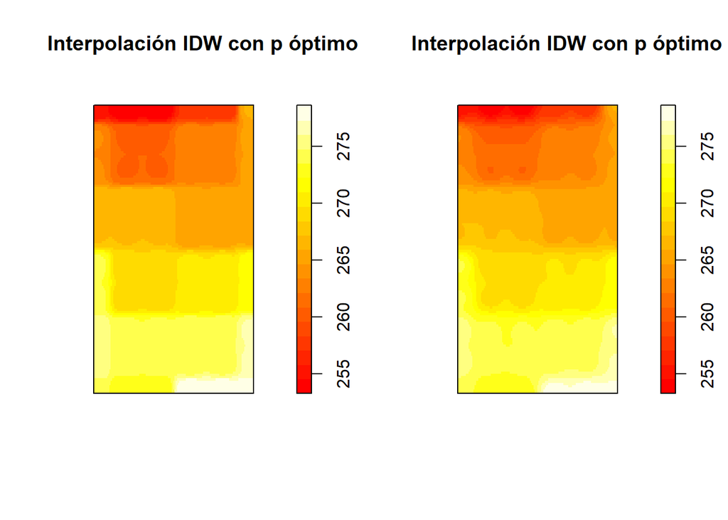

```r
par(mfrow=c(1,2))
idw_temp_optimo <- idw(ppp_temp, power = 6, at = "pixels")

plot(idw_temp_optimo,
     col = heat.colors(20),
     main = "Interpolación IDW con p óptimo")
idw_temp_optimo <- idw(ppp_temp, power = 3, at = "pixels")

plot(idw_temp_optimo,
     col = heat.colors(20),
     main = "Interpolación IDW con p óptimo")
```